# Introduction to regularization

```r
library(Matrix)
library(glmnet)
library(readxl)
library(dplyr)
library(caret)
library(superml)
```

### **I - Generation of the model :**

#### **1) Generation of the $X$ matrix:**

The matrix $X \in \mathbb{M}_{(n \text{,}p)}$, where $n = 10$ and $p = 100$. $X$ is not of full rank. Indeed, this is what we are looking for in this second lab in order to explore the three regularization methods. We start by generating our matrix by a normal law $\mathcal{N}(0,4)$ to have about the same number of positive and negative values.

```r
nrow = 10
ncol = 100
normal_distribution = rnorm(nrow*(ncol), mean = 0, sd = 2)
X = matrix(normal_distribution , nrow = nrow, ncol = ncol, byrow = TRUE)
```

#### **2) Génération de la matrice $Y$ :**

We generate a white noise $\epsilon$ by a normal law $\mathcal{N}(0,2)$ and $\beta = ({-2 , 7 , 0 \cdots , 0})$ the coefficient of our linear regression. Our target variable $Y$ thus satisfies the equation$Y = X\beta + \epsilon$.

```r
eps = c(rnorm(nrow, mean = 0, sd = sqrt(2)))
beta = c(-2,7, rep(0,ncol-2))
Y = X%*%beta + eps
```

#### **3) Calculation of the least squares estimator :**

We try to estimate $\beta$ by computing $\hat{\beta} = (X^t X)^{-1} X^t Y$.

```r
Beta_chapeau = solve(t(X)%*%X)%*%t(X)%*%Y
```

```
Error in solve.default(t(X) %*% X) :
  le système est numériquement singulier : conditionnement de la réciproque = 4.58077e-20
```

An error is returned. We should not be surprised by this result because $X$ is not of full rank and therefore not invertible, as well as $X^t X$ which is involved in the expression of $\hat{\beta}$.

#### **4)1) Estimation of $\hat{\beta}_{Ridge}$ :**

To remedy the problem of invertibility of $X^t X$ we use the first element of our toolbox which is the **Ridge regularization**. The method consists in estimating $\beta$ by computing $\hat{\beta}_{Ridge} = (X^t X + n\lambda I_n)^{-1} X^t Y$. We can prove the existence of such a $\lambda$ which makes the matrix $X^t X + n\lambda I_n$ invertible by exploiting the fact that $X^t X$ is symmetrical and then use the famous spectral theorem to obtain the diagonal matrix associated to $X^t X$ and then add $n\lambda I_n$ to it. We can also show that $\hat{\beta}_{Ridge}$ is the $argmin$ of the minimization problem of $||Y - X\beta||_2^2 + \lambda||\beta||_2^2$. The new estimator has a smaller variance i.e. $Var(\hat{\beta}_{Ridge}) < Var(\hat{\beta})$ but has a non zero bias.

```r
lamda = 1
Beta_ridge = solve(t(X)%*%X+lamda*diag(ncol))%*%t(X)%*%Y
```

The problem is thus circumvented for the calculation of $\hat{\beta}$. We will analyze the results of this regression in the rest of the notebook.

#### **4)2) Usage of Elastic Net with $\alpha = 0.5$:**

```r
res = glmnet(X,Y, alpha = 0.5, lambda = seq(0.5,10,0.1), intercept = FALSE, standardize = FALSE )
coef = as.data.frame(summary(coef(res, s=0.5)))
coef$j <- NULL
coef <- coef %>%
  rename(
    index = i,
    value = x
    )
coef <- coef[order(-abs(coef$value)),]
coef
```

|  | index | value |
| --- | --- | --- |
| 2 | 3 | 6.867526192 |
| 1 | 2 | -1.629010849 |
| 10 | 73 | -0.396711034 |
| 12 | 91 | 0.385852161 |
| 4 | 20 | -0.218787572 |
| 6 | 43 | 0.216027774 |
| 9 | 70 | -0.129706180 |
| 7 | 55 | 0.092219510 |
| 8 | 60 | -0.081141923 |
| 3 | 6 | 0.055071666 |

[output cut: 2 more lines]

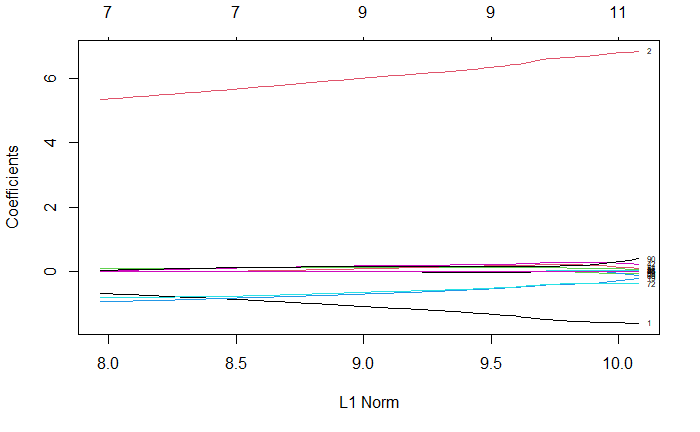

```r
plot(res, label = TRUE)
```

When $\lambda$ tends to 0, the determinant of $(X^t X)$ is close to 0, $(X^t X)^{-1}$ therefore contains very large values which intervene in the expression of $||\beta^\lambda||_1$. We can see in the graph below that $||\beta^\lambda||_1$ increases as $\lambda$ decreases.

#### **5) Utilisation de Lasso ($\alpha = 1$):**

```r
lasso = glmnet(X, Y, alpha = 1 , lambda = seq(0.5,10,0.1), intercept = FALSE, standardize = FALSE)

coef = as.data.frame(summary(coef(lasso, s=1)))
coef$j <- NULL
coef <- coef %>%
  rename(
    index = i,
    value = x
    )
coef <- coef[order(-abs(coef$value)),]
coef
```

|  | index | value |
| --- | --- | --- |
| 2 | 3 | 6.977069576 |
| 1 | 2 | -1.727598513 |
| 5 | 43 | 0.295272533 |
| 7 | 73 | -0.286596219 |
| 8 | 91 | 0.138677590 |
| 4 | 20 | -0.115098496 |
| 6 | 55 | 0.114814058 |
| 3 | 6 | 0.008711227 |

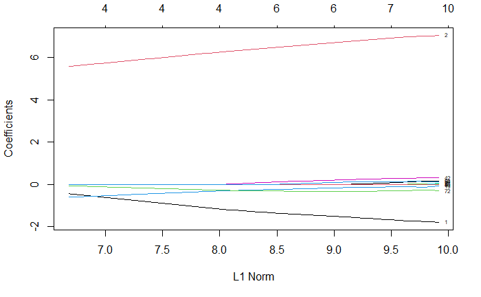

```r
plot(lasso, label = TRUE)
```

We obtain the solution of $||Y - X\beta||_2^2 + \lambda|||\beta|_1$ if and only if the **Karush-Kuhn-Tucker (KKT)** optimality conditions are satisfied. Considering the active set of $\hat{\beta}$ which we note $\hat{\Lambda}$ and which is defined by $\hat{\Lambda} = j \in \{1, \cdots , p\} : \hat{\beta}_j \ne 0\}$. We obtain the following constraints:
$$\begin{cases} 2X^t(Y-X\hat{\beta}) = \lambda sgn(\hat{\beta}_j) & \quad (\forall j \in \hat{\Lambda})\\ 2 \mid X^t(Y-X\hat{\beta})\mid < \lambda & \quad (\forall j \notin \hat{\Lambda})\end{cases}$$

We thus observe that the Lasso estimator is linear in terms of $lambda$. We can even find $K \in \mathbb{N}$ values of $\lambda$ for which the linearity changes. Also, we notice that Lasso favors parsimony, something we are interested in here because the number of variables is much higher than the number of observations.

#### **6) Correlated X columns:**

```r
normal_distribution_2 = rnorm(nrow*ncol/2, mean = 0 , sd = 10)

X2 = matrix(normal_distribution_2, nrow = nrow, ncol = ncol, byrow = FALSE)
X2[,51:100] = X2[,51:100] + rnorm(1, mean = 0 , sd = sqrt(0.01))
Y2 = X2%*%beta +eps
```

#### **7) Estimation of $\beta$ for $\alpha = 0, 0.5$ and $1$:**

```r
res = glmnet(X,Y, alpha = 0, lambda = seq(1,10,0.1), intercept = FALSE, standardize = FALSE )
coef = as.data.frame(summary(coef(res, s=1)))
coef$j <- NULL
coef <- coef %>%
  rename(
    index = i,
    value = x
    )
```

```r
coef[coef$index <52,]
```

|  | index | value |
| --- | --- | --- |
| 1 | 2 | -0.708523968 |
| 2 | 3 | 1.259951987 |
| 3 | 4 | -0.438320361 |
| 4 | 5 | 0.169049406 |
| 5 | 6 | 0.687800533 |
| 6 | 7 | 0.330352901 |
| 7 | 8 | -0.213951592 |
| 8 | 9 | -0.109324163 |
| 9 | 10 | -0.185209248 |
| 10 | 11 | 0.252846172 |

[output cut: 40 more lines]

```r
coef[coef$index >51,]
```

|  | index | value |
| --- | --- | --- |
| 51 | 52 | -5.512569e-03 |
| 52 | 53 | 1.313518e-01 |
| 53 | 54 | -9.714997e-02 |
| 54 | 55 | 3.866624e-01 |
| 55 | 56 | -2.026728e-01 |
| 56 | 57 | -3.293415e-01 |
| 57 | 58 | -1.142475e-01 |
| 58 | 59 | -8.713980e-02 |
| 59 | 60 | -1.905743e-01 |
| 60 | 61 | -3.708041e-02 |

[output cut: 40 more lines]

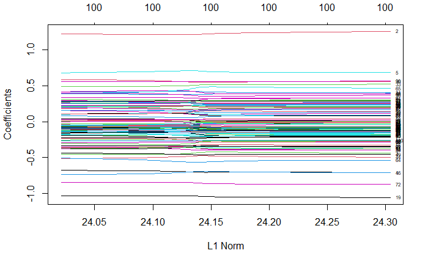

```r
plot(res, label = TRUE)
```

```r
res = glmnet(X,Y, alpha = 1, lambda = seq(1,10,0.1), intercept = FALSE, standardize = FALSE )
coef = as.data.frame(summary(coef(res, s=1)))
coef$j <- NULL
coef <- coef %>%
  rename(
    index = i,
    value = x
    )
```

```r
coef[coef$index <52,]
```

|  | index | value |
| --- | --- | --- |
| 1 | 2 | -1.727598513 |
| 2 | 3 | 6.977069576 |
| 3 | 6 | 0.008711227 |
| 4 | 20 | -0.115098496 |
| 5 | 43 | 0.295272533 |

```r
coef[coef$index >51,]
```

|  | index | value |
| --- | --- | --- |
| 6 | 55 | 0.1148141 |
| 7 | 73 | -0.2865962 |
| 8 | 91 | 0.1386776 |

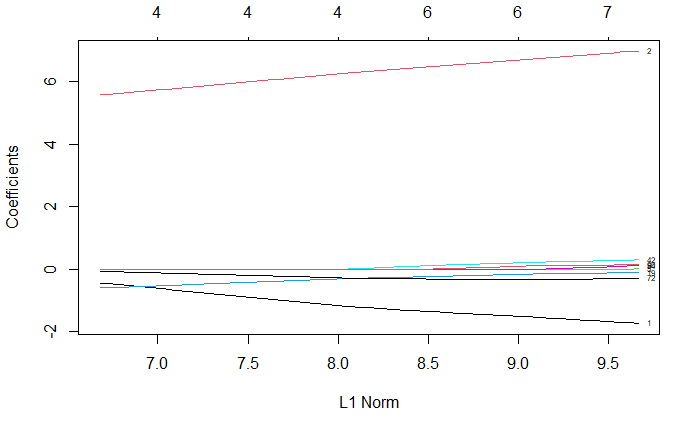

```r
plot(res, label = TRUE)
```

```r
res = glmnet(X,Y, alpha = 0.5, lambda = seq(1,10,0.1), intercept = FALSE, standardize = FALSE )
coef = as.data.frame(summary(coef(res, s=1)))
coef$j <- NULL
coef <- coef %>%
  rename(
    index = i,
    value = x
    )
```

```r
coef[coef$index <52,]
```

|  | index | value |
| --- | --- | --- |
| 1 | 2 | -1.60185380 |
| 2 | 3 | 6.72933180 |
| 3 | 6 | 0.08370085 |
| 4 | 20 | -0.37530046 |
| 5 | 25 | 0.01701657 |
| 6 | 43 | 0.26539665 |

```r
coef[coef$index >51,]
```

|  | index | value |
| --- | --- | --- |
| 7 | 55 | 0.180028187 |
| 8 | 60 | -0.055250305 |
| 9 | 70 | -0.007920519 |
| 10 | 73 | -0.398541321 |
| 11 | 91 | 0.192074186 |

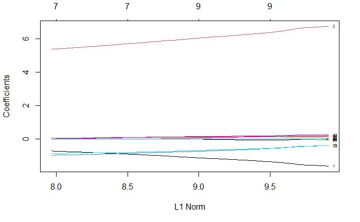

```r
plot(res, label = TRUE)
```

#### **9) Cross Validation:**

```r
res_val = cv.glmnet(X, Y, alpha = 0.5)
MSE_lambda = res_val$cvm
MSE_lambda = as.data.frame(MSE_lambda)
Values_lambda = res_val$lambda
Values_lambda = as.data.frame(Values_lambda)
```

```r
Cross_val = cbind(Values_lambda,MSE_lambda)
Cross_val <- Cross_val[order(abs(Cross_val$MSE_lambda)),]
Cross_val
```

|  | Values_lambda | MSE_lambda |
| --- | --- | --- |
| s87 | 0.6173467 | 110.9405 |
| s86 | 0.6467421 | 111.0008 |
| s85 | 0.6775372 | 111.1027 |
| s84 | 0.7097987 | 111.3587 |
| s83 | 0.7435963 | 111.6513 |
| s82 | 0.7790032 | 111.9614 |
| s81 | 0.8160960 | 112.3089 |
| s80 | 0.8549550 | 112.6776 |
| s79 | 0.8956644 | 113.0645 |
| s78 | 0.9383121 | 113.4690 |

[output cut: 78 more lines]

### **II - Real data example:**

#### **1) Boston housing data:**

```r
housing_data = read_excel('housing.xlsx')
Y = housing_data$CRIM
X = housing_data[,!names(housing_data) %in% c('CRIM')]

res = cv.glmnet(as.matrix(X),Y, alpha = 1)

lambda_opt = res$lambda[which.min(res$cvm)]

coef = as.data.frame(summary(coef(res, s = lambda_opt)))
coef$j <- NULL
coef <- coef %>%
  rename(
    index = i,
    value = x
    )
coef <- coef[order(-abs(coef$value)),]
coef
```

|  | index | value |
| --- | --- | --- |
| 1 | 1 | 12.666630967 |
| 5 | 5 | -6.966972639 |
| 7 | 8 | -0.787816118 |
| 4 | 4 | -0.585263575 |
| 8 | 9 | 0.514355221 |
| 6 | 6 | 0.229498614 |
| 9 | 11 | -0.188016174 |
| 12 | 14 | -0.157926207 |
| 11 | 13 | 0.125278643 |
| 3 | 3 | -0.070797081 |

[output cut: 2 more lines]

```r
res = glmnet(as.matrix(X),Y, alpha = 1, lambda = 1)

coef = as.data.frame(summary(coef(res, s = 1)))
coef$j <- NULL
coef <- coef %>%
  rename(
    index = i,
    value = x
    )
coef <- coef[order(-abs(coef$value)),]
coef
```

|  | index | value |
| --- | --- | --- |
| 1 | 1 | -0.503749992 |
| 2 | 9 | 0.434479189 |
| 4 | 13 | 0.116084514 |
| 5 | 14 | -0.021407462 |
| 3 | 12 | -0.002854706 |

#### **2) Forest Fire data:**

```r
forest_data = read.csv('forestfires.csv')
droplist = c('month', 'day', 'area')
Y = forest_data[,13]
X = forest_data[, !colnames(forest_data) %in% droplist]
```

```r
forest_cv = cv.glmnet(as.matrix(X),Y, alpha = 0.5, intercept = FALSE)

lambda_opt = forest_cv$lambda[which.min(forest_cv$cvm)]

coef = as.data.frame(summary(coef(forest_cv, s = lambda_opt)))
coef$j <- NULL
coef <- coef %>%
  rename(
    index = i,
    value = x
    )
coef <- coef[order(-abs(coef$value)),]
coef <- coef[order(coef$index),]
coef
```

|  | index | value |
| --- | --- | --- |
| 1 | 2 | 1.59110093 |
| 2 | 3 | 0.13754820 |
| 3 | 4 | -0.01221890 |
| 4 | 5 | 0.05464395 |
| 5 | 7 | -0.36727500 |
| 6 | 8 | 0.51747974 |
| 7 | 9 | -0.21431135 |
| 8 | 10 | 0.73809255 |
| 9 | 11 | -0.23635641 |

```r
lasso_cv = cv.glmnet(as.matrix(X),Y, alpha = 1)

lasso_lambda = lasso_cv$lambda[which.min(lasso_cv$cvm)]

coef = as.data.frame(summary(coef(lasso_cv, s = lasso_lambda)))
coef$j <- NULL
coef <- coef %>%
  rename(
    index = i,
    value = x
    )
coef <- coef[order(-abs(coef$value)),]
coef
```

|  | index | value |
| --- | --- | --- |
| 1 | 1 | -3.0219243 |
| 2 | 2 | 1.5060734 |
| 8 | 10 | 0.6379911 |
| 6 | 8 | 0.5582152 |
| 5 | 7 | -0.2708310 |
| 3 | 3 | 0.1916102 |
| 7 | 9 | -0.1781454 |
| 4 | 5 | 0.0472505 |

```r
res = lm( area ~ Xaxis + Yaxis + FFMC + DMC + DC + ISI + temp + RH + wind + rain, data = forest_data)
summary(res)
```

```
Call:
lm(formula = area ~ Xaxis + Yaxis + FFMC + DMC + DC + ISI + temp +
    RH + wind + rain, data = forest_data)

Residuals:
    Min      1Q  Median      3Q     Max
 -39.36  -15.89   -8.54   -0.29 1065.45

Coefficients:
             Estimate Std. Error t value Pr(>|t|)
(Intercept) -6.369315  63.019477  -0.101    0.920
Xaxis        1.907945   1.448367   1.317    0.188
Yaxis        0.569181   2.736327   0.208    0.835
FFMC        -0.039200   0.660756  -0.059    0.953
DMC          0.077335   0.067161   1.151    0.250
DC          -0.003295   0.016452  -0.200    0.841
ISI         -0.713739   0.771506  -0.925    0.355
temp         0.800213   0.787185   1.017    0.310
RH          -0.230645   0.237305  -0.972    0.332
wind         1.557431   1.670088   0.933    0.352
rain        -3.404037   9.680970  -0.352    0.725

Residual standard error: 63.58 on 506 degrees of freedom
Multiple R-squared:  0.02164,   Adjusted R-squared:  0.002305
F-statistic: 1.119 on 10 and 506 DF,  p-value: 0.3454
```